# Feature Engineering--

### There is not any clear relationship between the number of items on promotion and number of sales. The sales are already in logrithmic scale, probably I have to do this on raw sales count.

```python
promo_2017_train.columns= promo_2017_train.columns.droplevel()
```

```python
promo_2017_train.columns.get_level_values(1)
```

```
DatetimeIndex(['2017-01-01', '2017-01-02', '2017-01-03', '2017-01-04',
               '2017-01-05', '2017-01-06', '2017-01-07', '2017-01-08',
               '2017-01-09', '2017-01-10',
               ...
               '2017-08-06', '2017-08-07', '2017-08-08', '2017-08-09',
               '2017-08-10', '2017-08-11', '2017-08-12', '2017-08-13',
               '2017-08-14', '2017-08-15'],
              dtype='datetime64[ns]', name='date', length=227, freq=None)
```

```python
df_test.head()
```

| store_nbr | item_nbr | date | id | onpromotion |
| --- | --- | --- | --- | --- |
| 1 | 96995 | 2017-08-16 | 125497040 | False |
|  | 99197 | 2017-08-16 | 125497041 | False |
|  | 103501 | 2017-08-16 | 125497042 | False |
|  | 103520 | 2017-08-16 | 125497043 | False |
|  | 103665 | 2017-08-16 | 125497044 | False |

```python
# promotion columns from training data
promo_2017_train.columns = promo_2017_train.columns.get_level_values(1)
```

```python
# promotion data from test data
promo_2017_test = df_test[["onpromotion"]].unstack(level=-1).fillna(False)
```

```python
promo_2017_test.head()
```

| store_nbr | date item_nbr | onpromotion 2017-08-16 | onpromotion 2017-08-17 | onpromotion 2017-08-18 | onpromotion 2017-08-19 | onpromotion 2017-08-20 | onpromotion 2017-08-21 | onpromotion 2017-08-22 | onpromotion 2017-08-23 | onpromotion 2017-08-24 | onpromotion 2017-08-25 | onpromotion 2017-08-26 | onpromotion 2017-08-27 | onpromotion 2017-08-28 | onpromotion 2017-08-29 | onpromotion 2017-08-30 | onpromotion 2017-08-31 |
| --- | --- | --- | --- | --- | --- | --- | --- | --- | --- | --- | --- | --- | --- | --- | --- | --- | --- |
| 1 | 96995 | False | False | False | False | False | False | False | False | False | False | False | False | False | False | False | False |
|  | 99197 | False | False | False | False | False | False | False | False | False | False | False | False | False | False | False | False |
|  | 103501 | False | False | False | False | False | False | False | False | False | False | False | False | False | False | False | False |
|  | 103520 | False | False | False | False | False | False | False | False | False | False | False | False | False | False | False | False |
|  | 103665 | False | False | False | False | False | False | False | False | False | False | False | False | False | False | False | False |

Test data Strats from 2017-08-16 to 2017-08-31

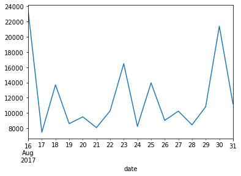

```python
promo_2017_test.sum(axis=0).plot()
```

It is a bit of cheating, as I am not suppose to look at test data at all while building the model. Anyway, the number of items on promotion in test period are same on average.

```python
promo_2017_test.columns = promo_2017_test.columns.get_level_values(1)

promo_2017_test = promo_2017_test.reindex(promo_2017_train.index).fillna(False)
```

```python
promo_2017_test.head()
```

| store_nbr | date item_nbr | 2017-08-16 | 2017-08-17 | 2017-08-18 | 2017-08-19 | 2017-08-20 | 2017-08-21 | 2017-08-22 | 2017-08-23 | 2017-08-24 | 2017-08-25 | 2017-08-26 | 2017-08-27 | 2017-08-28 | 2017-08-29 | 2017-08-30 | 2017-08-31 |
| --- | --- | --- | --- | --- | --- | --- | --- | --- | --- | --- | --- | --- | --- | --- | --- | --- | --- |
| 1 | 96995 | False | False | False | False | False | False | False | False | False | False | False | False | False | False | False | False |
|  | 99197 | False | False | False | False | False | False | False | False | False | False | False | False | False | False | False | False |
|  | 103520 | False | False | False | False | False | False | False | False | False | False | False | False | False | False | False | False |
|  | 103665 | False | False | False | False | False | False | False | False | False | False | False | False | False | False | False | False |
|  | 105574 | False | False | False | False | False | False | False | False | False | False | False | False | False | False | False | False |

```python
promo_2017_train.head()
```

| store_nbr | date item_nbr | 2017-01-01 | 2017-01-02 | 2017-01-03 | 2017-01-04 | 2017-01-05 | 2017-01-06 | 2017-01-07 | 2017-01-08 | 2017-01-09 | 2017-01-10 | ... | 2017-08-06 | 2017-08-07 | 2017-08-08 | 2017-08-09 | 2017-08-10 | 2017-08-11 | 2017-08-12 | 2017-08-13 | 2017-08-14 | 2017-08-15 |
| --- | --- | --- | --- | --- | --- | --- | --- | --- | --- | --- | --- | --- | --- | --- | --- | --- | --- | --- | --- | --- | --- | --- |
| 1 | 96995 | False | False | False | False | False | False | False | False | False | False | ... | False | False | False | False | False | False | False | False | False | False |
|  | 99197 | False | False | False | False | False | False | False | False | False | False | ... | False | False | False | False | False | False | False | False | False | False |
|  | 103520 | False | False | False | False | False | False | False | False | False | False | ... | False | False | False | False | False | False | False | False | False | False |
|  | 103665 | False | False | False | False | False | False | False | False | False | False | ... | False | False | False | False | False | False | False | False | False | False |
|  | 105574 | False | False | True | False | False | True | False | False | False | False | ... | False | False | False | False | False | False | False | False | False | False |

5 rows × 227 columns

```python
promo_2017 = pd.concat([promo_2017_train, promo_2017_test], axis=1)
```

```python
# Combined the promotion data from training and test data
promo_2017 = pd.concat([promo_2017_train, promo_2017_test], axis=1)
```

```python
promo_2017.head()
```

| store_nbr | date item_nbr | 2017-01-01 | 2017-01-02 | 2017-01-03 | 2017-01-04 | 2017-01-05 | 2017-01-06 | 2017-01-07 | 2017-01-08 | 2017-01-09 | 2017-01-10 | ... | 2017-08-22 | 2017-08-23 | 2017-08-24 | 2017-08-25 | 2017-08-26 | 2017-08-27 | 2017-08-28 | 2017-08-29 | 2017-08-30 | 2017-08-31 |
| --- | --- | --- | --- | --- | --- | --- | --- | --- | --- | --- | --- | --- | --- | --- | --- | --- | --- | --- | --- | --- | --- | --- |
| 1 | 96995 | False | False | False | False | False | False | False | False | False | False | ... | False | False | False | False | False | False | False | False | False | False |
|  | 99197 | False | False | False | False | False | False | False | False | False | False | ... | False | False | False | False | False | False | False | False | False | False |
|  | 103520 | False | False | False | False | False | False | False | False | False | False | ... | False | False | False | False | False | False | False | False | False | False |
|  | 103665 | False | False | False | False | False | False | False | False | False | False | ... | False | False | False | False | False | False | False | False | False | False |
|  | 105574 | False | False | True | False | False | True | False | False | False | False | ... | False | False | False | False | False | False | False | False | False | False |

5 rows × 243 columns

## Working on Traget Variable:

In this problem, our traget variable is unit_sales.

```python
df_2017_tmp = df_2017.set_index(
    ["store_nbr", "item_nbr", "date"])[["unit_sales"]].unstack(
        level=-1)
```

```python
df_sale_count = pd.DataFrame()
```

```python
df_sale_count['coverage'] = df_2017_tmp.count(axis=0)
df_sale_count['coverage_ffill'] = df_2017_tmp.fillna(0).count(axis=0)
```

```python
df_sale_count = df_sale_count.unstack(level=0)
```

```python
df_sale_count.columns = ['coverage', 'coverage_ffill']
```

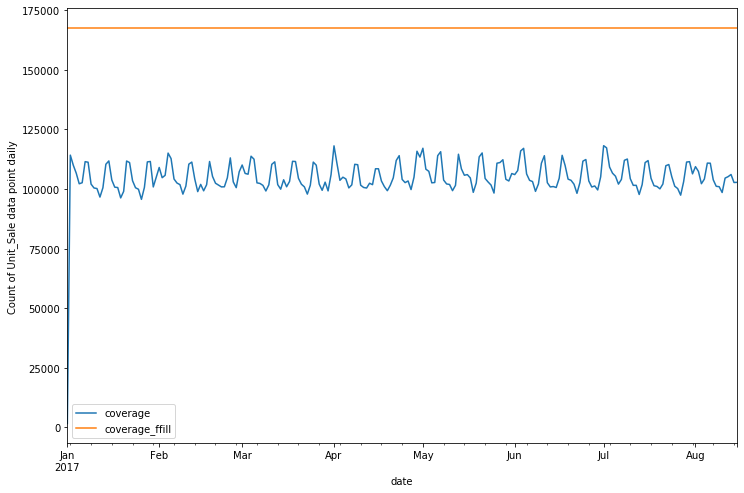

```python
df_sale_count.plot(figsize=(12,8))
plt.ylabel('Count of Unit_Sale data point daily')
```

# Question: How to handle missing values????

There are reasonable number of missing values for unit sales as can be seen from above plot. In the solution, they filled with 0, however I am not fully convinced whether it is the right way to handle missing data in training set.

Based on my limited knowledge of grocery data, I can think of following reason about this issue

1. Data is actually not cleaned
2. All stores do not have same inventory of items
3. New items are being added--this very week argument

## Possible Solutions:

There can be many solutions and we have to study the data in depth. However, I aim to try below.

1. Fill with 0 as proposed
2. Drop the row where target sales are 0
3. Forward fill with average of last N days
4. Forward fill with average of last N-same week days ( As we have seen the sales are different on different week day)

# Solution # 3

Forward fill the missing sales with last 20 days average sales

```python
df_target_sales = df_2017_tmp['unit_sales'].T

df_target_sales_rolling_mean = df_target_sales.rolling(window=20, min_periods=1).mean()

df_target_sales_filled_3 = df_target_sales.add(df_target_sales_rolling_mean[~ df_target_sales.notnull()], fill_value=0)

df_target_sales_filled_3.T
```

[output not shown]

```python
df_target_sales.T.shape
```

```
(167515, 227)
```

```python
df_2017 = df_2017.set_index(
    ["store_nbr", "item_nbr", "date"])[["unit_sales"]].unstack(
        level=-1).fillna(0)



df_2017.columns = df_2017.columns.get_level_values(1)
```

```python
stores.head()
```

| store_nbr | city | state | type | cluster |
| --- | --- | --- | --- | --- |
| 1 | 18 | 12 | 3 | 13 |
| 2 | 18 | 12 | 3 | 13 |
| 3 | 18 | 12 | 3 | 8 |
| 4 | 18 | 12 | 3 | 9 |
| 5 | 21 | 14 | 3 | 4 |

```python
items = items.reindex(df_2017.index.get_level_values(1))
stores = stores.reindex(df_2017.index.get_level_values(0))
```

```python
items.head()
```

| item_nbr | family | class | perishable |
| --- | --- | --- | --- |
| 96995 | 12 | 1093 | 0 |
| 99197 | 12 | 1067 | 0 |
| 103520 | 12 | 1028 | 0 |
| 103665 | 5 | 2712 | 1 |
| 105574 | 12 | 1045 | 0 |

```python
stores.head()
```

| store_nbr | city | state | type | cluster |
| --- | --- | --- | --- | --- |
| 1 | 18 | 12 | 3 | 13 |
| 1 | 18 | 12 | 3 | 13 |
| 1 | 18 | 12 | 3 | 13 |
| 1 | 18 | 12 | 3 | 13 |
| 1 | 18 | 12 | 3 | 13 |

```python
df_2017_item = df_2017.groupby('item_nbr')[df_2017.columns].sum()
promo_2017_item = promo_2017.groupby('item_nbr')[promo_2017.columns].sum()
```

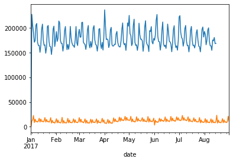

```python
df_2017_item.sum(axis=0).plot()
promo_2017_item.sum(axis=0).plot()
```

```python
items.head()
```

| item_nbr | family | class | perishable |
| --- | --- | --- | --- |
| 96995 | 12 | 1093 | 0 |
| 99197 | 12 | 1067 | 0 |
| 103520 | 12 | 1028 | 0 |
| 103665 | 5 | 2712 | 1 |
| 105574 | 12 | 1045 | 0 |

```python
df_2017_store_class = df_2017.reset_index()
```

```python
df_2017_store_class.head()
```

[output not shown]

5 rows × 230 columns

```python
df_2017_store_class['class'] = items['class'].values
```

```python
df_2017_store_class_index = df_2017_store_class[['class', 'store_nbr']]
df_2017_store_class = df_2017_store_class.groupby(['class', 'store_nbr'])[df_2017.columns].sum()
```

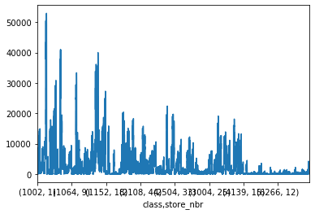

```python
df_2017_store_class.sum(axis=1).plot()
```

```python
df_2017_promo_store_class = promo_2017.reset_index()
df_2017_promo_store_class['class'] = items['class'].values
df_2017_promo_store_class_index = df_2017_promo_store_class[['class', 'store_nbr']]
df_2017_promo_store_class = df_2017_promo_store_class.groupby(['class', 'store_nbr'])[promo_2017.columns].sum()
```

```python
def get_timespan(df, dt, minus, periods, freq='D'):

    return df[pd.date_range(dt - timedelta(days=minus), periods=periods, freq=freq)]
```

```python
def prepare_dataset(df, promo_df, t2017, is_train=True, name_prefix=None):
    X = {
        "promo_14_2017": get_timespan(df = promo_df, dt= t2017, minus=14, periods=14, freq='D').sum(axis=1).values,
        "promo_60_2017": get_timespan(df = promo_df, dt = t2017, minus = 60, periods = 60).sum(axis=1).values,
        "promo_140_2017": get_timespan(df = promo_df, dt = t2017, minus = 140, periods = 140).sum(axis=1).values,
        "promo_3_2017_aft": get_timespan(promo_df, t2017 + timedelta(days=16), 15, 3).sum(axis=1).values,
        "promo_7_2017_aft": get_timespan(promo_df, t2017 + timedelta(days=16), 15, 7).sum(axis=1).values,
        "promo_14_2017_aft": get_timespan(promo_df, t2017 + timedelta(days=16), 15, 14).sum(axis=1).values,
    }

    for i in [3, 7, 14, 30, 60, 140]:
        tmp1 = get_timespan(df, t2017, i, i)
        tmp2 = (get_timespan(promo_df, t2017, i, i) > 0) * 1

        X['has_promo_mean_%s' % i] = (tmp1 * tmp2.replace(0, np.nan)).mean(axis=1).values
        X['has_promo_mean_%s_decay' % i] = (tmp1 * tmp2.replace(0, np.nan) * np.power(0.9, np.arange(i)[::-1])).sum(axis=1).values

        X['no_promo_mean_%s' % i] = (tmp1 * (1 - tmp2).replace(0, np.nan)).mean(axis=1).values
        X['no_promo_mean_%s_decay' % i] = (tmp1 * (1 - tmp2).replace(0, np.nan) * np.power(0.9, np.arange(i)[::-1])).sum(axis=1).values

    for i in [3, 7, 14, 30, 60, 140]:
        tmp = get_timespan(df, t2017, i, i)
        X['diff_%s_mean' % i] = tmp.diff(axis=1).mean(axis=1).values
        X['mean_%s_decay' % i] = (tmp * np.power(0.9, np.arange(i)[::-1])).sum(axis=1).values
        X['mean_%s' % i] = tmp.mean(axis=1).values
        X['median_%s' % i] = tmp.median(axis=1).values
        X['min_%s' % i] = tmp.min(axis=1).values
        X['max_%s' % i] = tmp.max(axis=1).values
        X['std_%s' % i] = tmp.std(axis=1).values

    for i in [3, 7, 14, 30, 60, 140]:
        tmp = get_timespan(df, t2017 + timedelta(days=-7), i, i)
        X['diff_%s_mean_2' % i] = tmp.diff(axis=1).mean(axis=1).values
        X['mean_%s_decay_2' % i] = (tmp * np.power(0.9, np.arange(i)[::-1])).sum(axis=1).values
        X['mean_%s_2' % i] = tmp.mean(axis=1).values
        X['median_%s_2' % i] = tmp.median(axis=1).values
        X['min_%s_2' % i] = tmp.min(axis=1).values
        X['max_%s_2' % i] = tmp.max(axis=1).values
        X['std_%s_2' % i] = tmp.std(axis=1).values

    for i in [7, 14, 30, 60, 140]:
        tmp = get_timespan(df, t2017, i, i)
        X['has_sales_days_in_last_%s' % i] = (tmp > 0).sum(axis=1).values
        X['last_has_sales_day_in_last_%s' % i] = i - ((tmp > 0) * np.arange(i)).max(axis=1).values
        X['first_has_sales_day_in_last_%s' % i] = ((tmp > 0) * np.arange(i, 0, -1)).max(axis=1).values

        tmp = get_timespan(promo_df, t2017, i, i)
        X['has_promo_days_in_last_%s' % i] = (tmp > 0).sum(axis=1).values
        X['last_has_promo_day_in_last_%s' % i] = i - ((tmp > 0) * np.arange(i)).max(axis=1).values
        X['first_has_promo_day_in_last_%s' % i] = ((tmp > 0) * np.arange(i, 0, -1)).max(axis=1).values

    tmp = get_timespan(promo_df, t2017 + timedelta(days=16), 15, 15)
    X['has_promo_days_in_after_15_days'] = (tmp > 0).sum(axis=1).values
    X['last_has_promo_day_in_after_15_days'] = i - ((tmp > 0) * np.arange(15)).max(axis=1).values
    X['first_has_promo_day_in_after_15_days'] = ((tmp > 0) * np.arange(15, 0, -1)).max(axis=1).values

    for i in range(1, 16):
        X['day_%s_2017' % i] = get_timespan(df, t2017, i, 1).values.ravel()

    for i in range(7):
        X['mean_4_dow{}_2017'.format(i)] = get_timespan(df, t2017, 28-i, 4, freq='7D').mean(axis=1).values
        X['mean_20_dow{}_2017'.format(i)] = get_timespan(df, t2017, 140-i, 20, freq='7D').mean(axis=1).values

    for i in range(-16, 16):
        X["promo_{}".format(i)] = promo_df[t2017 + timedelta(days=i)].values.astype(np.uint8)

    X = pd.DataFrame(X)

    if is_train:
        y = df[
            pd.date_range(t2017, periods=16)
        ].values
        return X, y
    if name_prefix is not None:
        X.columns = ['%s_%s' % (name_prefix, c) for c in X.columns]
    return X

print("Preparing dataset...")
t2017 = date(2017, 6, 14)
num_days = 6
X_l, y_l = [], []
for i in range(num_days):
    delta = timedelta(days=7 * i)
    X_tmp, y_tmp = prepare_dataset(df_2017, promo_2017, t2017 + delta)

    X_tmp2 = prepare_dataset(df_2017_item, promo_2017_item, t2017 + delta, is_train=False, name_prefix='item')
    X_tmp2.index = df_2017_item.index
    X_tmp2 = X_tmp2.reindex(df_2017.index.get_level_values(1)).reset_index(drop=True)

    X_tmp3 = prepare_dataset(df_2017_store_class, df_2017_promo_store_class, t2017 + delta, is_train=False, name_prefix='store_class')
    X_tmp3.index = df_2017_store_class.index
    X_tmp3 = X_tmp3.reindex(df_2017_store_class_index).reset_index(drop=True)

    X_tmp = pd.concat([X_tmp, X_tmp2, X_tmp3, items.reset_index(), stores.reset_index()], axis=1)
    X_l.append(X_tmp)
    y_l.append(y_tmp)

    del X_tmp2
    gc.collect()
```

```
Preparing dataset...
```

```python
X_train = pd.concat(X_l, axis=0)
y_train = np.concatenate(y_l, axis=0)

# del X_l, y_l

# Prepare Validation data set
val_start_date = date(2017, 7, 26)
X_val, y_val = prepare_dataset(df_2017, promo_2017, val_start_date )

X_val2 = prepare_dataset(df_2017_item, promo_2017_item, val_start_date, is_train=False, name_prefix='item')
X_val2.index = df_2017_item.index
X_val2 = X_val2.reindex(df_2017.index.get_level_values(1)).reset_index(drop=True)

X_val3 = prepare_dataset(df_2017_store_class, df_2017_promo_store_class, val_start_date, is_train=False, name_prefix='store_class')
X_val3.index = df_2017_store_class.index
X_val3 = X_val3.reindex(df_2017_store_class_index).reset_index(drop=True)

X_val = pd.concat([X_val, X_val2, X_val3, items.reset_index(), stores.reset_index()], axis=1)

# Prepare Test data set
test_start_date = date(2017, 8, 16)
X_test = prepare_dataset(df_2017, promo_2017,test_start_date , is_train=False)

X_test2 = prepare_dataset(df_2017_item, promo_2017_item,test_start_date, is_train=False, name_prefix='item')
X_test2.index = df_2017_item.index
X_test2 = X_test2.reindex(df_2017.index.get_level_values(1)).reset_index(drop=True)

X_test3 = prepare_dataset(df_2017_store_class, df_2017_promo_store_class, test_start_date, is_train=False, name_prefix='store_class')
X_test3.index = df_2017_store_class.index
X_test3 = X_test3.reindex(df_2017_store_class_index).reset_index(drop=True)

X_test = pd.concat([X_test, X_test2, X_test3, items.reset_index(), stores.reset_index()], axis=1)

# del X_test2, X_val2, df_2017_item, promo_2017_item, df_2017_store_class, df_2017_promo_store_class, df_2017_store_class_index
gc.collect()
```

```
45279
```